# Plotting

Rebecca Folmer Schade

27 dec 2020

The purpose of this project is to illustrate and shed further light on the intricacies of why open data is still lacking in scientific research, despite much time spendt as a hot topic in the debate on a chaning scintific process.

To do this, I will attempt to plot data I have collected from a small survey of data sharing practices at Aarhus University, Denmark (though the data I have collected so far is not suficient for a statistical analysis).

The goal is for these plots to be:  
- easily readable  
- informative  
- comparable to each-other

## Setup

Though the data has been cleaned (see Data_cleaning_markdown.Rmd), I will need help from the *'tidiverse'* package to manipulate it into a shape more beneficient to visialisation, as well as plotting the data.

```r
# calling the tidyverse package
library(tidyverse)
```

The cleaned dataset can be found within the *'data'* folder of this project. Its file name is *'clean_dataset.csv'*, and I load it into an object (of the class *'tibble'*) called *'aarhus_survey'* below.

```r
# Loading clean dataset
aarhus_survey <- read_csv("data/clean_dataset.csv")
```

## Manipulating data

The data in *'aarhus_survey'*, while clean, is not in the right format for plotting. In this section, I will change that.

```r
# Creating a new column for separating the data into two groups - Students and Academics
aarhus_survey <- aarhus_survey %>%
  mutate(demographic = ifelse(position == "student", "Students", "Academics"))

# Subsetting the dataframe to the questions I need for visualization
sub_survey <- aarhus_survey[,c(8,10,12,13,15,16,20,22)]

# Making a list of the new names of the columns
# Some of these names only contain the last part of the question
# That is because the first part will be in the plot title
colnames(sub_survey) <- c("How important is open data?",
                          "Share data after publication?", # Starts "is it important to"
                          "Share your data after publication?", # Starts "How often do you"
                          "Share data before publication?", # Starts "is it important to"
                          "Share your data before publication?", # Starts "How often do you"
                          "Make your data public?", # Starts "How often do you"
                          "Use other people\'s data?", # Starts "How often do you"
                          "Demographic")
```

I will be making three different plots; One with importance rated in a likert scale, one with importance rated with a binary scale, and one with frequency rated in a likert scale.

```r
#=====> Making data from the importance question the right format for plotting
# Subsetting only the columns I need
importance <- sub_survey[,c(1,8)]

# Making the data Long format
importance_long <- importance %>% gather(question, category, 1, factor_key=TRUE)

# Summarising the data by question, category and demographic
importance_agg <- importance_long %>%
  group_by(question, category, Demographic) %>%
  dplyr::summarise(total = n())

# Adding a column showing percentages for plotting
importance_sum <- importance_agg %>%
  group_by(Demographic) %>% # Grouping by demographic...
  mutate(countT = sum(total)) %>% # ...so the total number of answers are calculated by demographic
  group_by(category, add=TRUE) %>% # Grouping by category...
  mutate(per=round(100*total/countT,2)) # ..so the percenteges are calculated by category and demographic

# Turning category into a factor so I can order the labels after importance for plotting
importance_sum$category <- as.factor(importance_sum$category)
# Ordering the labels
importance_sum$category <-
  ordered(importance_sum$category,
          levels = c("not important",
                     "slightly important",
                     "neutral",
                     "important",
                     "very important"))


#=====> Making data from the binary questions the right format for plotting
# Subsetting only the columns I need
binary <- sub_survey[,c(2,4,8)]

# Making the data Long format
binary_long <- binary %>% gather(question, category, 1:2, factor_key=TRUE)

# Summarising the data by question, category and demographic
binary_agg <- binary_long %>% group_by(question, category, Demographic) %>% dplyr::summarise(total = n())

# Adding a column showing percentages for plotting
binary_sum <- binary_agg %>%
  group_by(question, Demographic) %>% # Grouping by demographic and question...
  mutate(countT= sum(total)) %>% # ...so the total number of answers are calculated by the two variables
  group_by(category, add=TRUE) %>% # Grouping by category...
  mutate(per=round(100*total/countT,2)) # ..so the percenteges are calculated by all three varaibles

# Turning category into a factor so I can order the labels for plotting
binary_sum$category <- as.factor(binary_sum$category)
# Ordering the labels
binary_sum$category <-
  ordered(binary_sum$category,
          levels = c("no", "yes"))


#=====> Making the data from the frequency questions the right format for plotting
# Subsetting only the columns I need and filtering the students out of the sample
freq <- sub_survey[,c(3,5,6,7,8)] %>% filter(Demographic == "Academics")

# Making the data Long format
freq_long <- freq %>% gather(question, category, 1:4, factor_key=TRUE)

# Summarising the data by question and category
freq_agg <- freq_long %>% group_by(question, category) %>% dplyr::summarise(total = n())

# Adding a column showing percentages for plotting
freq_sum <- freq_agg %>%
  group_by(question) %>% # Grouping by question...
  mutate(countT= sum(total)) %>% # ...so the total number of answers are calculated by question
  group_by(category, add=TRUE) %>% # Grouping by category...
  mutate(per=round(100*total/countT,2)) # ..so the percenteges are calculated by question and category

# Turning category into a factor so I can order the labels after frequency for plotting
freq_sum$category <- as.factor(freq_sum$category)
# Ordering the labels
freq_sum$category <-
  ordered(freq_sum$category,
          levels = c("never", "rarely", "sometimes", "often", "always"))
```

## Plotting

For importance

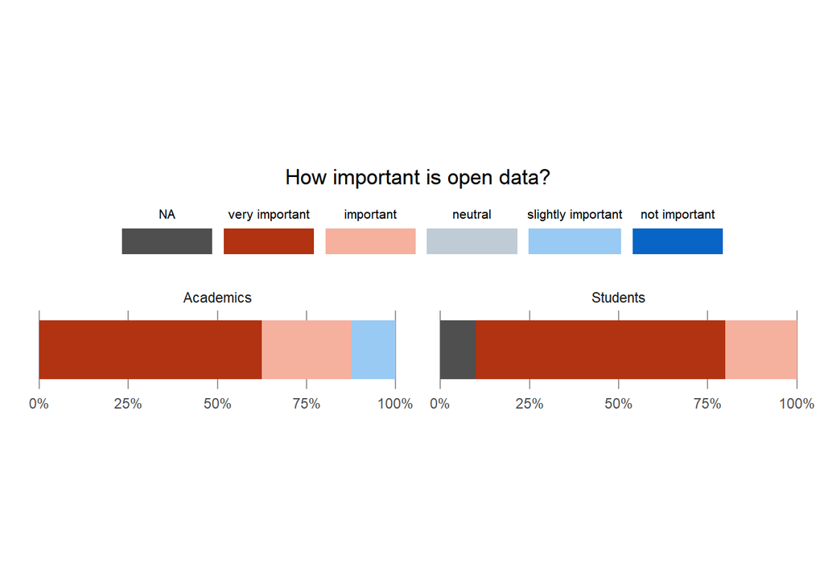

```r
# Creating the plot
ggplot(data = importance_sum, aes(x =question , y = per, fill = category)) +
  # Making it a bar plot
  geom_bar(stat="identity") +
  # Applying custom color scheme
  scale_fill_manual (values=likert_palette,
                     labels=levels(importance_sum$category),
                     drop = FALSE,
                     na.value = "#4F4F4F") +
  # Flipping the bars from vertical to horizontal
  coord_flip() +
  # Removing axis titles for simplicity and adding a plot title
  labs(x = element_blank(), y = element_blank(), title = "How important is open data?") +
  # Adding the custom theme
  showcase_theme +
  # Removing the y axis ticks to save space
  theme(axis.text.y = element_blank()) +
  # Adding %-signs to the x axis
  scale_y_continuous(labels = function(x) paste0(x, "%")) +
  # Changing the position of the legend
  guides(fill = guide_legend(nrow = 1, label.position = "top", reverse = TRUE)) +
  # Facetting the plot by demographic
  facet_wrap(~Demographic)
```

```r
# Saving the plot
ggsave("output/importance_plot.jpg")
```

For binary data

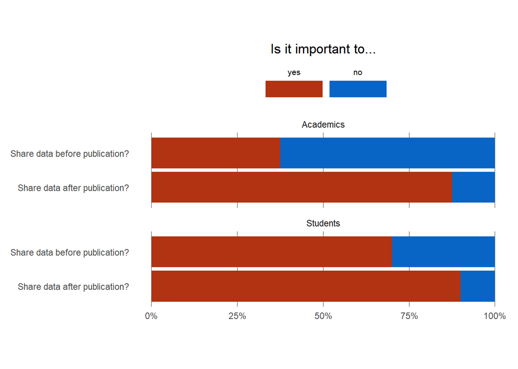

```r
# Creating the plot
ggplot(data = binary_sum, aes(x =question , y = per, fill = category)) +
  # Making it a bar plot
  geom_bar(stat="identity") +
  # Applying custom color scheme
  scale_fill_manual (values=binary_palette,
                     labels=levels(binary_sum$category),
                     drop = FALSE,
                     na.value = "#4F4F4F") +
  # Flipping the bars from vertical to horizontal
  coord_flip() +
  # Removing axis titles for simplicity and adding a plot title
  labs(x = element_blank(), y = element_blank(), title = "Is it important to...") +
  # Adding the custom theme
  showcase_theme +
  # Adding %-signs to the x axis
  scale_y_continuous(labels = function(x) paste0(x, "%")) +
  # Changing the position of the legend
  guides(fill = guide_legend(nrow = 1, label.position = "top", reverse = TRUE)) +
  # Facetting the plot by demographic, and specifying the direction of the facets
  facet_wrap(~Demographic, dir = "v")
```

```r
# Saving the plot
ggsave("output/binary_plot.jpg")
```

For frequency data

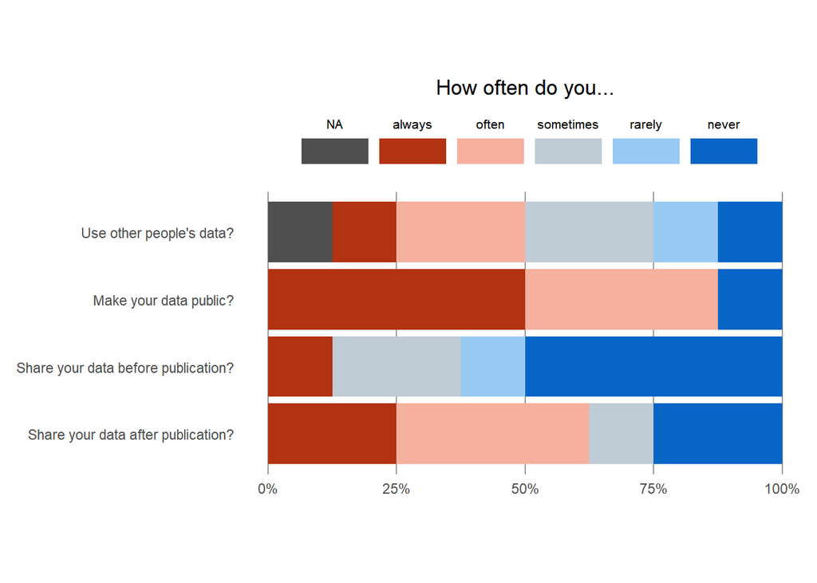

```r
# Creating the plot
ggplot(data = freq_sum, aes(x =question , y = per, fill = category)) +
  # Making it a bar plot
  geom_bar(stat="identity") +
  # Applying custom color scheme
  scale_fill_manual (values=likert_palette,
                     labels=levels(freq_sum$category),
                     drop = FALSE,
                     na.value = "#4F4F4F") +
  # Flipping the bars from vertical to horizontal
  coord_flip() +
  # Removing axis titles for simplicity and adding a plot title
  labs(x = element_blank(), y = element_blank(), title = "How often do you...") +
  # Adding the custom theme
  showcase_theme +
  # Changing the plot's aspect ratio betweewn x and y axis and adjusting the size of the legend
  theme(aspect.ratio = 2/4, legend.key.width = unit(1.5, "cm")) +
  # Adding %-signs to the x axis
  scale_y_continuous(labels = function(x) paste0(x, "%")) +
  # Changing the position of the legend
  guides(fill = guide_legend(nrow = 1, label.position = "top", reverse = TRUE))
```

```r
# Saving the plot
ggsave("output/frequency_plot.jpg")
```